# MA331-Report: 2211911

TED Talks by Speaker Hans Rosling and Speaker Deborah Gordon

Ruhela, Tanu

## Introduction

This report examines TED talks given by *Hans Rosling* and *Deborah Gordon*. *Hans Rosling* was a Swedish physician, academic, and statistician, who used his expertise in data analysis to shed light on important global issues such as health and poverty. On the other hand, Deborah Gordon is a biologist who has devoted her career to studying ants and their behavior. Her TED talks delve into the fascinating world of ant colonies, where she reveals the intricate social systems and hierarchies that exist within these tiny creatures. The below headlines are being focused in the report

- “The Best Stats You’ve Ever Seen” by Hans Rosling (2006)
- “New Insights on Poverty” by Hans Rosling (2007)
- “Insights on HIV, in Stunning Data Visuals” by Hans Rosling (2009)
- “The Emergent Genius of Ant Colonies” by Deborah Gordon (2003)
- “What Ants Teach Us About the Brain, Cancer and the Internet” by Deborah Gordon (2014)

The report aims to answer questions about the main themes of these talks, what are the most frequent used words by the speakers, how the language usage and sentiment of the talks differs of both speakers and check if there are any patterns or themes that can be brought up from the analysis of these talks

## Methods

The interpretation of both the speakers will be as follows.

Firstly, *Tidying and Tokenization* help in structuring the words by converting them to tokens and then my removing the stop words using unnest_tokens(), anti_join() and get_stopwords(). Secondly, Word Frequency Analysis is being implemented to identify the most frequent words used by the speakers in the talks by grouping, filtering and slicing. Then, the Odds-Ratios technique helps in comparing the emotions of the two ted speakers. It can be done by using compute_OR() and log_OR() functions used in dsEssex

In the report further, Sentiment Analysis helps to differentiate the patterns of speakers and what are the most used emotions. NRC Sentiment and Emotion lexicons will be used to analyze it.

Overall, this report aims to provide a comprehensive understanding how Hans Rosling and Deborah Gordon usually delivers there speech. What are their most common words while delivering the speech and what are their emotions.

## Results

The first step is to tokenize and remove the stop words from both the speakers. The glimpse of both speakers can be seen below:

```
# A tibble: 6 × 3
  speaker      word          n
  <chr>        <chr>     <int>
1 Hans Rosling can          63
2 Hans Rosling world        59
3 Hans Rosling countries    46
4 Hans Rosling now          45
5 Hans Rosling like         38
6 Hans Rosling see          37
```

```
# A tibble: 6 × 3
  speaker        word         n
  <chr>          <chr>    <int>
1 Deborah Gordon ants       108
2 Deborah Gordon ant         57
3 Deborah Gordon colony      53
4 Deborah Gordon nest        53
5 Deborah Gordon colonies    31
6 Deborah Gordon just        30
```

The below graph displays top 10 words of both speakers. By interpreting the below graphs, we can say that the most often words used by *Hans Rosling* while explaining the world statistical issues of health and poverty are ‘can’, ‘world’, ‘countries’ and ‘now’. On the other hand *Deborah Gordon* used ‘ants’, ‘nest’, ‘colony’, ‘workers’ and ‘maintenance’ mostly. This helps us depict the over view she explained about the ant colonies and how they work.

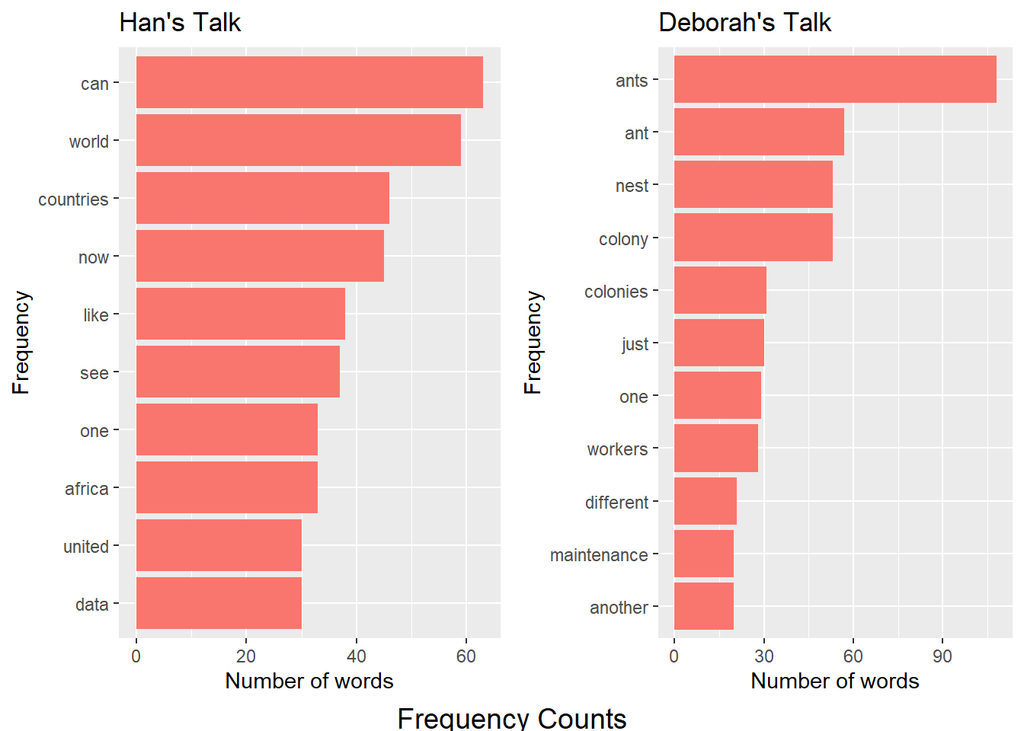

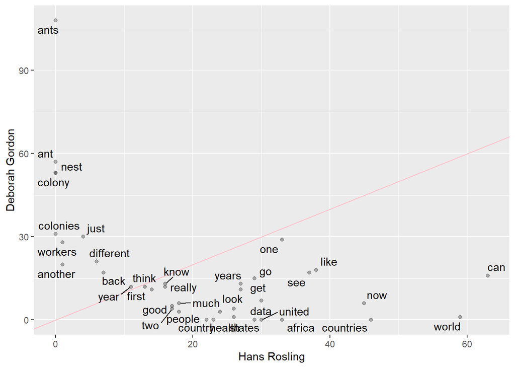

The below table and graph represents the log values of odds ratio. It can be seen that the most common emotions used by *Hans Rosling* (positive axes) are fear, anger, joy, negative, anticipation and sadness while giving his talk on global statistics, poverty and health, he anticipates the future outcome based on the present activities, whereas *Deborah Gordon* (negative axes) uses trust, positive, surprise and disgust emotions in her speech of ants.

```
# A tibble: 10 × 5
   sentiment    `Deborah Gordon` `Hans Rosling`    OR   log_OR
   <fct>                   <int>          <int> <dbl>    <dbl>
 1 sadness                    18             35 1.17   0.160
 2 anticipation               34             65 1.16   0.150
 3 negative                   39             74 1.16   0.145
 4 joy                        31             55 1.07   0.0658
 5 anger                      12             21 1.05   0.0476
 6 fear                       22             37 1.01   0.00652
 7 trust                      53             86 0.965 -0.0352
 8 positive                   90            139 0.899 -0.106
 9 surprise                   23             34 0.877 -0.131
10 disgust                    16             19 0.700 -0.356
```

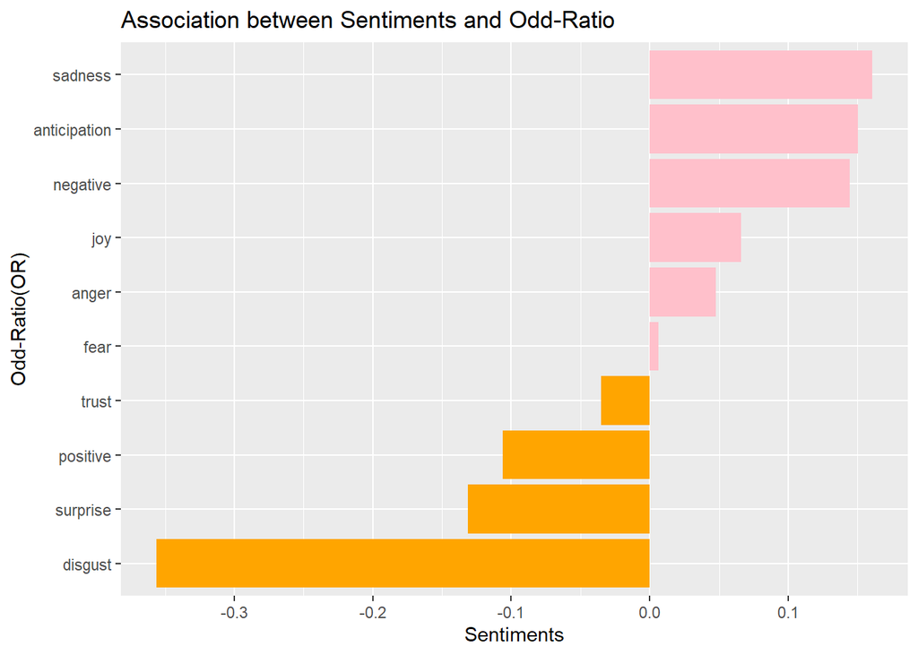

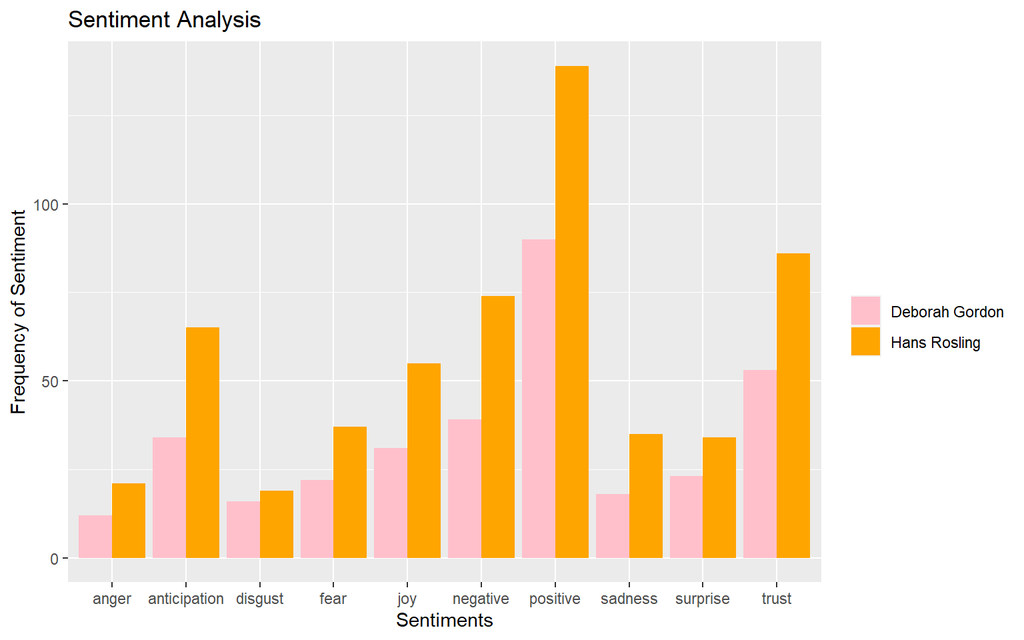